# New seal analysis

Peter Ditchfield

2026-04-30

## New seal standard analysis

First load in the data for the standards from the two runs. This has already been tidied up in excel. The calibration, check standards and Salanine results have been separated out.

The data for the standards are in the files Salanine-for-R.csv and certified_standards.csv They should be in the folder with this document.

In each case it will be useful to have both case it will be useful to have name and run as factors

```r
 Salanine$Name <- as.factor(Salanine$Name)
  Salanine$Run <- as.factor(Salanine$Run)
  measured_standards$Name <- as.factor(measured_standards$Name)
  measured_standards$Run <- as.factor(measured_standards$Run)
```

### Working with the Salanine data first.

The accepted alanine values used for the lab are the 2022 external calibration values provided by SERCON. which are $\delta$ <sup>13</sup>C = -27.18 ‰ (VPDB) with a standard deviation of 0.01 and $\delta$ <sup>15</sup>N = -1.51 ‰ (AIR) with a standard deviation of 0.01

These can be compared to the measured values for these runs in Fig.1a

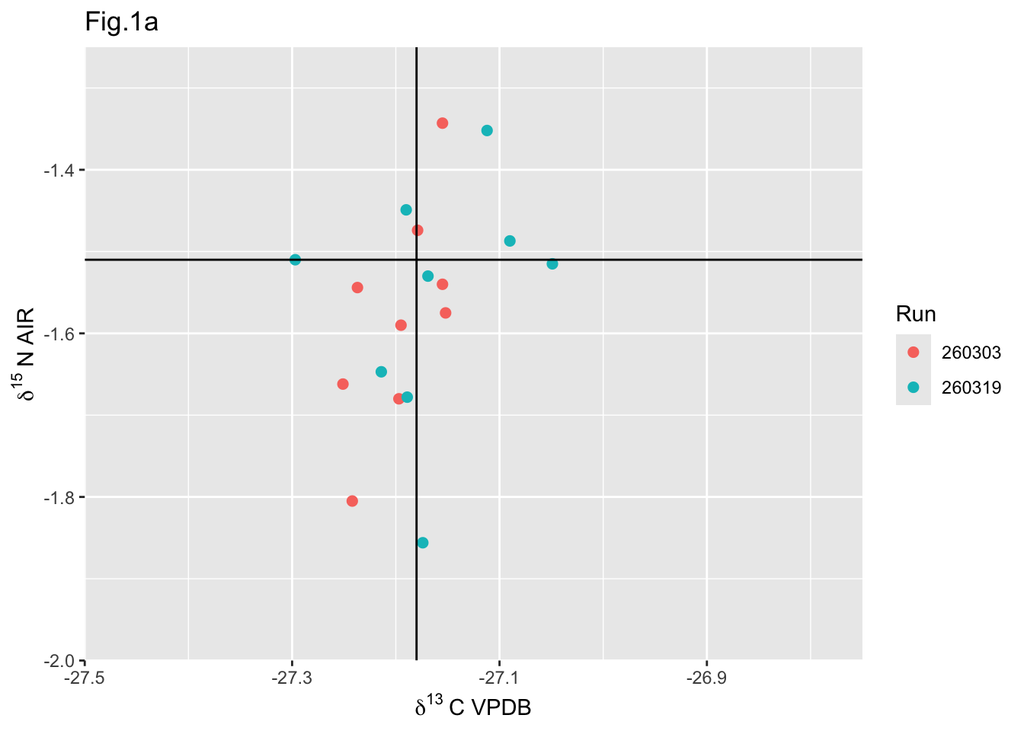

```r
# simple plot of d13C v d15N coloured by burn number
library(ggplot2)
F1a <-  ggplot(data = Salanine, aes(x = d13C_VPDB, y = d15N_AIR, color = Run)) +
  geom_point(size = 2, show.legend = TRUE)+
  geom_vline(xintercept = -27.18)+
  geom_hline(yintercept = -1.51)+
  coord_cartesian(xlim = c (-27.5, -26.75), ylim = c (-2,-1.25), expand = FALSE, default = FALSE, clip = "on")+
  ggtitle("Fig.1a")+
  labs(y = delta ^15~'N AIR' , x = delta ^13~'C VPDB')

F1a
```

The measured values show a reasonable scatter about the accepted values although there is a slight skew towards more negative values of 15N. Also there is an apparent correlation between $\delta$ <sup>13</sup>C and $\delta$ <sup>15</sup>N which is concerning, see fig.1b.

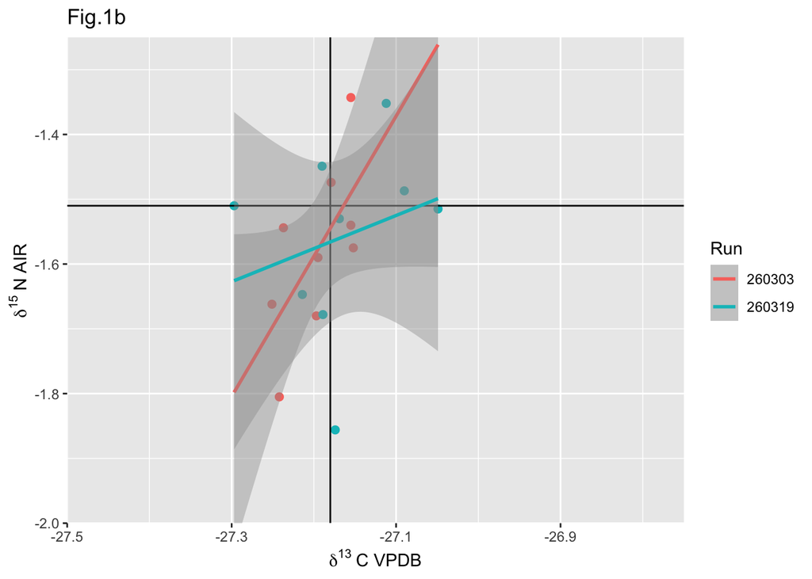

```r
F1b <-  ggplot(data = Salanine, aes(x = d13C_VPDB, y = d15N_AIR, colour = Run)) +
  geom_point(size = 2, show.legend = FALSE)+
  geom_vline(xintercept = -27.18)+
  geom_hline(yintercept = -1.51)+
  coord_cartesian(xlim = c (-27.5, -26.75), ylim = c (-2,-1.25), expand = FALSE, default = FALSE, clip = "on")+
  ggtitle("Fig.1b")+
  labs(y = delta ^15~'N AIR' , x = delta ^13~'C VPDB')

F1b+
  geom_smooth( method = "lm",
               formula = y ~ x, fullrange =TRUE)
```

This could be due to them both having a strong linearity effect with sample size.

Lets see how strongly correlated they are.

```r
mod1 <- lm(formula = d15N_AIR ~ d13C_VPDB, data = Salanine)

summary(mod1)
```

```
##
## Call:
## lm(formula = d15N_AIR ~ d13C_VPDB, data = Salanine)
##
## Residuals:
##       Min        1Q    Median        3Q       Max
## -0.292813 -0.057370 -0.002603  0.088581  0.203727
##
## Coefficients:
##             Estimate Std. Error t value Pr(>|t|)
## (Intercept)  21.9790    14.4537   1.521    0.148
## d13C_VPDB     0.8664     0.5318   1.629    0.123
##
## Residual standard error: 0.13 on 16 degrees of freedom
## Multiple R-squared:  0.1423, Adjusted R-squared:  0.08868
## F-statistic: 2.654 on 1 and 16 DF,  p-value: 0.1228
```

So with an R-squared value of 0.1423 and p-value of 0.1228 they are not very strongly correlated (although checking the linearity with size would be worthwhile. This side quest can be found in the doc linearity.rmd ).

#### Calculate some basic stats for the measured Alanines

```r
# for N15
Salanine_mean_d15N <- mean(Salanine$d15N_AIR)
Salanine_mean_d15N<- signif(Salanine_mean_d15N,4)
Salanine_sd_d15N <- sd(Salanine$d15N_AIR)
Salanine_sd_d15N <- signif(Salanine_sd_d15N,3)
#for C13
Salanine_mean_d13C <- mean(Salanine$d13C_VPDB)
Salanine_mean_d13C <-signif(Salanine_mean_d13C,4)
Salanine_sd_d13C  <- sd(Salanine$d13C_VPDB)
Salanine_sd_d13C  <- signif(Salanine_sd_d13C, 3)
```

The mean value for $\delta$ <sup>13</sup>C is -27.18 ‰ (VPDB) with a standard deviation of 0.0593 ‰. The excepted value is -27.18‰ (VPDB) with an sd of 0.01‰.

The mean value for $\delta$ <sup>15</sup>N is -1.569 ‰ (AIR) with a standard deviation of 0.136 ‰. The excepted value is -1.51‰ (AIR) with an sd of 0.01‰. So there is a small offset of ca. -0.06 ‰ in the measured values and the sd for the measured values is larger.

#### Distributions of the measured values

##### First for $\delta$ <sup>13</sup>C

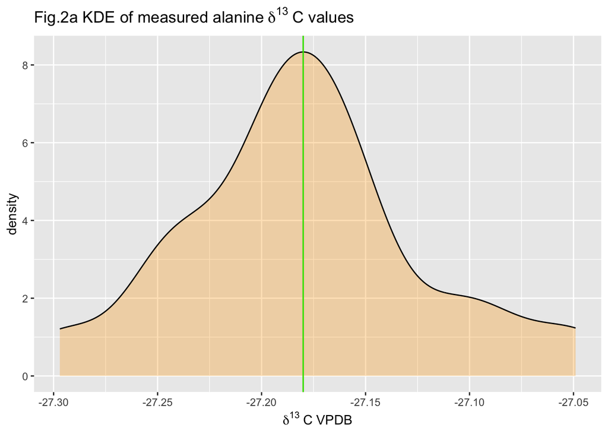

```r
F2a <- ggplot(Salanine, aes(d13C_VPDB)) +
  geom_density( fill = "orange", alpha = 0.3) +
  geom_vline(xintercept = -27.18, color = "red")+
  geom_vline(xintercept = (Salanine_mean_d13C), color = "green")+
 labs(x = delta ^13~'C VPDB' , y = 'density', title =  quote ("Fig.2a KDE of measured alanine" ~ delta ^13~'C values'))

F2a
```

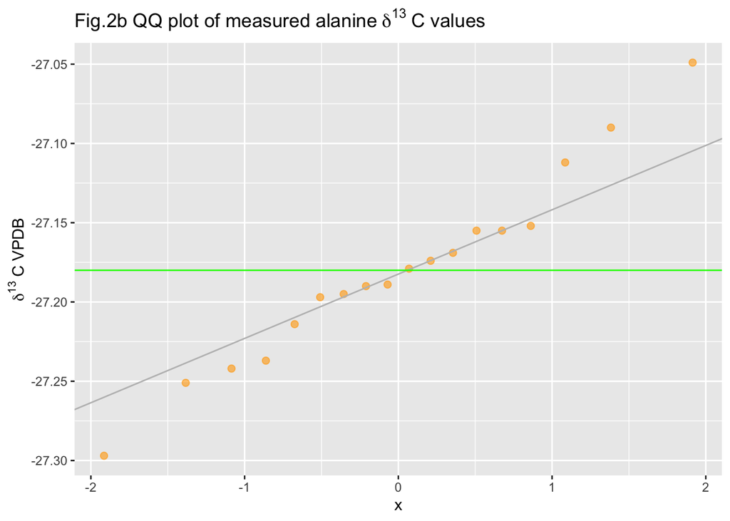

```r
F2b <- ggplot(Salanine, aes(sample = d13C_VPDB)) +
  stat_qq(size=2, color= "orange", alpha = 0.6) +
  stat_qq_line(col = "grey") +
  geom_hline(yintercept = -27.18, colour = "green")+
  labs( y = delta ^13~'C VPDB', title =  quote ("Fig.2b QQ plot of measured alanine" ~ delta ^13~'C values'))

F2b
```

These both look reasonable with a relatively normal shaped distribution and a mean at very close to accepted value of -27.18‰.

Note this is different to the regression line calibrated value of -27.193‰. In this case the regression line correction would be over correcting samples at or near to the working standard value.

##### Next for $\delta$ <sup>15</sup>N

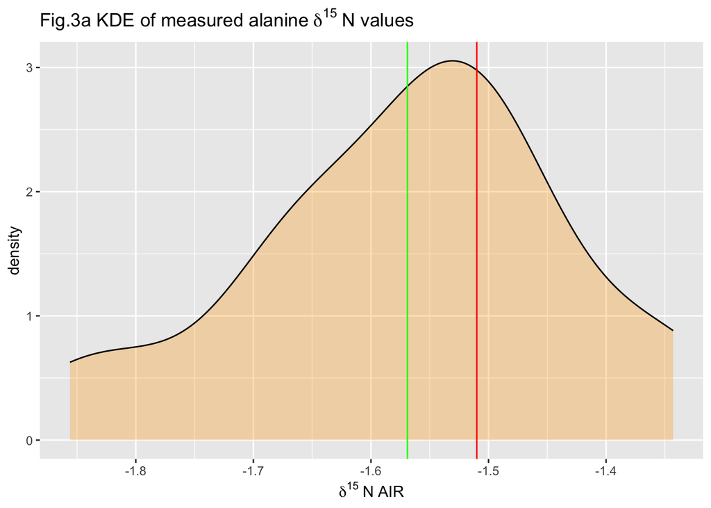

```r
F3a <- ggplot(Salanine, aes(d15N_AIR)) +
  geom_density( fill = "orange", alpha = 0.3) +
  geom_vline(xintercept = -1.51, color = "red")+
  geom_vline(xintercept = (Salanine_mean_d15N), color = "green")+
 labs(x = delta ^15~'N AIR' , y = 'density', title =  quote ("Fig.3a KDE of measured alanine" ~ delta ^15~'N values'))

F3a
```

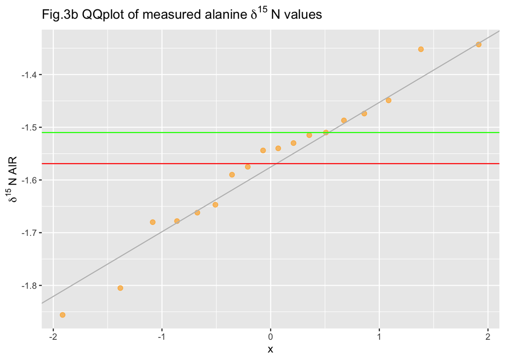

```r
F3b <- ggplot(Salanine, aes(sample = d15N_AIR)) +
  stat_qq(size=2, color= "orange", alpha = 0.6) +
  stat_qq_line(col = "grey") +
  geom_hline(yintercept = -1.51, colour = "green")+
  geom_hline(yintercept = -1.569, color = "red")+
  labs( y = delta ^15~'N AIR', title =  quote ("Fig.3b QQplot of measured alanine" ~ delta ^15~'N values'))

F3b
```

This distribution looks OK, but not as good as the carbon data, with a less normal shaped distribution and with a mean of -1.569 ‰ that is displaced by ca. 0.06‰ from the accepted value for the alanine $\delta$ <sup>15</sup>N.

### Working with the other standards in the runs.

These data are stored in the measured_standards data frame. We have already made ‘Run’ and ‘Name’ factors.

The data frame contains results for four standards USGS40, USGS41, USGS88 and IAEA C6. Note, IAEA C6 does not have meaningful $\delta$ <sup>15</sup>N data as it is sucrose and contains no Nitrogen.

```r
# check the data frame structure
  str(measured_standards)
```

```
## 'data.frame':    33 obs. of  12 variables:
##  $ Position      : int  7 21 28 42 7 21 28 42 10 17 ...
##  $ Name          : Factor w/ 4 levels "IAEAC6","USGS40",..: 1 1 1 1 1 1 1 1 2 2 ...
##  $ Weight_mg     : num  1.04 0.91 1.15 1.12 1.08 1.12 1.1 1.01 1.11 0.94 ...
##  $ N_ug          : num  0.697 0.569 0.598 0.579 0.896 ...
##  $ d15N_AIR      : num  -3.459 -9.687 -4.923 -4.38 0.793 ...
##  $ C_ug          : num  435 384 478 468 449 ...
##  $ d13C_VPDB     : num  -10.6 -10.7 -10.6 -10.6 -10.5 ...
##  $ d18O_VPDB     : num  -48.6 -46.8 -48.6 -47.6 -47.8 ...
##  $ Run           : Factor w/ 4 levels "260303","260319",..: 1 1 1 1 2 2 2 2 1 1 ...
##  $ C.N_molar     : num  729 786 932 944 584 ...
##  $ d13C_certified: num  -10.4 -10.4 -10.4 -10.4 -10.4 ...
##  $ uncertainty   : num  0.03 0.03 0.03 0.03 0.03 0.03 0.03 0.03 0.04 0.04 ...
```

```r
  # should be 33 obs. of  12 variables
```

Starting with the N bearing standards USGS40 and USGS88. Subset them from the measured standards data frame and make a cross plot.

#### Cross plot for Nitrogen bearing standards

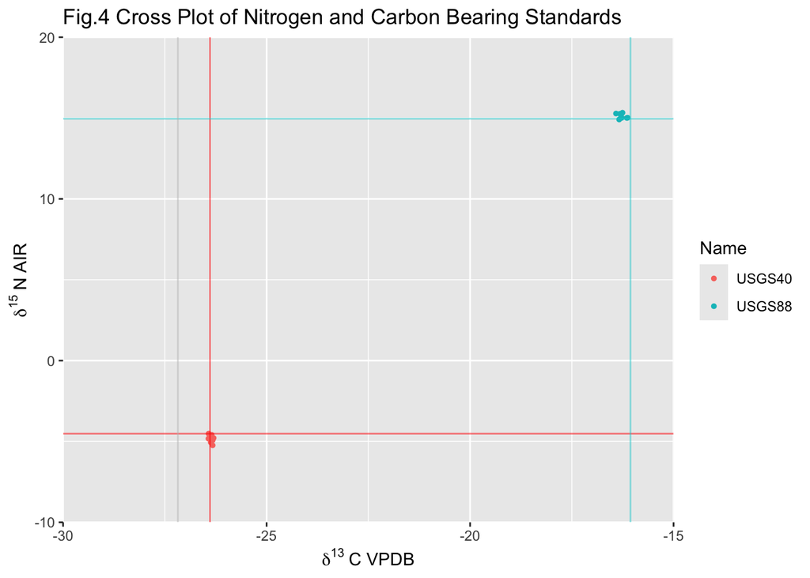

```r
F4 <-  ggplot(data = measured_usgs, aes(x = d13C_VPDB, y = d15N_AIR, color = Name)) +
  geom_point(size = 1, show.legend = TRUE)+
coord_cartesian(xlim = c (-30, -15), ylim = c (-10, 20), expand = FALSE, default = FALSE, clip = "on")+
  labs(y = delta ^15~'N AIR' , x = delta ^13~'C VPDB', title =  quote ("Fig.4 Cross Plot of Nitrogen and Carbon Bearing Standards"))+
  geom_hline(yintercept = -4.52, color = "red", alpha=0.5)+
  geom_vline(xintercept = -26.39,color = "red", alpha=0.5)+
geom_hline(yintercept = 14.96, color = "darkturquoise", alpha=0.5)+
  geom_vline(xintercept = -16.06,color = "darkturquoise", alpha=0.5)+
  geom_vline(xintercept = -27.18,color = "grey", alpha=0.5)

F4
```

So no clear scale compression for $\delta$ <sup>15</sup>N but moderate scale compression for $\delta$ <sup>13</sup>C at the less negative end i.e. as we move away from the $\delta$ <sup>13</sup>C value of the working standard alanine in the positive direction.

This is typical of the scale compression seen on this instrument and we need to make a scale compression correction.

#### Calculate some basic stats for measured USGS 40

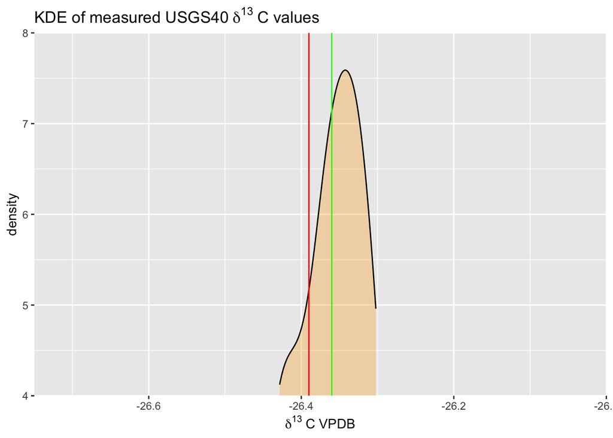

```r
F5a <- ggplot(measured_usgs40, aes(d13C_VPDB)) +
  geom_density( fill = "orange", alpha = 0.3) +
  geom_vline(xintercept = -26.39, color = "red")+
  geom_vline(xintercept = (measured_usgs40_mean_d13C), color = "green")+
 labs(x = delta ^13~'C VPDB' , y = 'density', title =  quote ("KDE of measured USGS40" ~ delta ^13~'C values'))+
  coord_cartesian(xlim = c (-26.75, -26), ylim = c (4, 8), expand = FALSE, default = FALSE, clip = "on")


F5a
```

So the mean measured $\delta$ <sup>13</sup>C is very close ca. + 0.03‰ compared to the certified $\delta$ <sup>13</sup>C value for USGS40.

### USGS 88

Calculate some basic stats for measured USGS 88

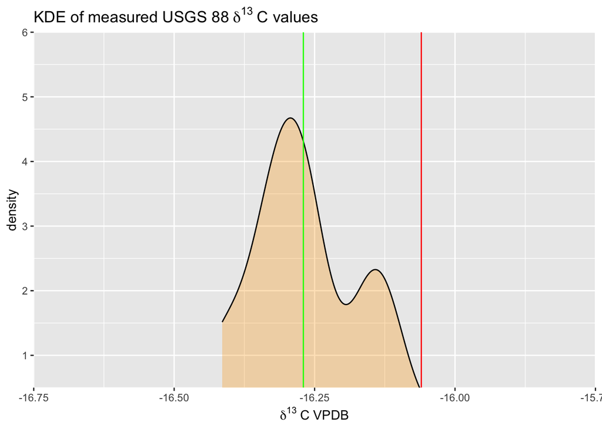

```r
F6a <- ggplot(measured_usgs88, aes(d13C_VPDB)) +
  geom_density( fill = "orange", alpha = 0.3) +
  geom_vline(xintercept = -16.06, color = "red")+
  geom_vline(xintercept = (measured_usgs88_mean_d13C), color = "green")+
 labs(x = delta ^13~'C VPDB' , y = 'density', title =  quote ("KDE of measured USGS 88" ~ delta ^13~'C values'))+
  coord_cartesian(xlim = c (-16.75, -15.75), ylim = c (0.5, 6), expand = FALSE, default = FALSE, clip = "on")


F6a
```

The mean measured $\delta$ <sup>13</sup>C is undermeasuerd by (ca. + 0.2‰) compared to the certified $\delta$ <sup>13</sup>C value for USGS88.

### IAEA C6 $\delta$ <sup>13</sup>C data

Calculate some basic stats for measured IAEAC6

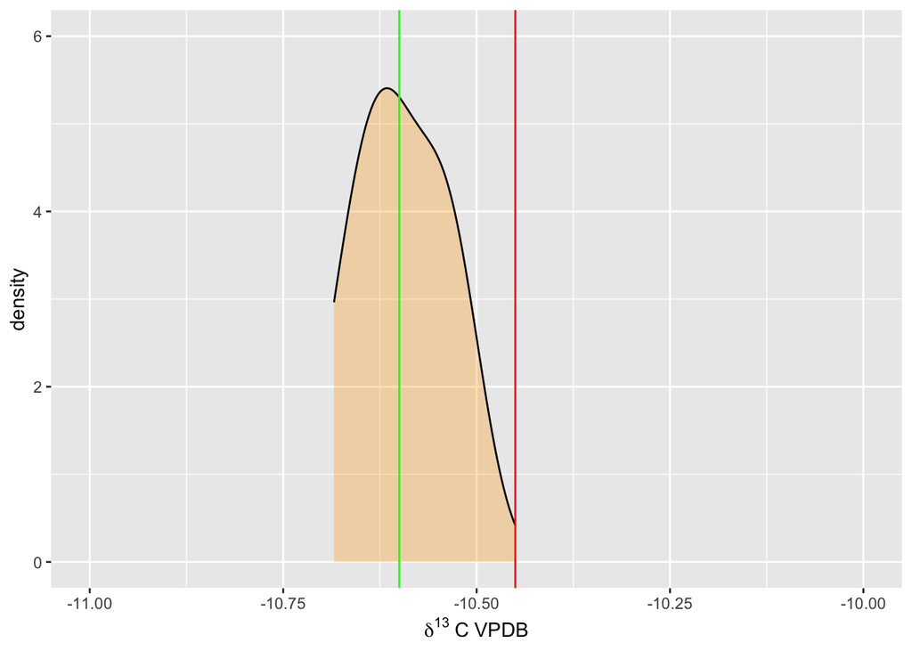

```r
F7a <- ggplot(measured_iaeaC6, aes(d13C_VPDB)) +
  geom_density( fill = "orange", alpha = 0.3) +
  geom_vline(xintercept = -10.45, color = "red")+
  geom_vline(xintercept = (measured_iaeaC6_mean_d13C), color = "green")+
 labs(x = delta ^13~'C VPDB' , y = 'density', )+
  #labs( title =  quote ("KDE of measured IAEA C6" ~ delta ^13~'C values'))+
  coord_cartesian(xlim = c (-11, -10), ylim = c (0, 6), expand = TRUE, default = FALSE, clip = "on")


F7a
```

The mean measured $\delta$ <sup>13</sup>C is undermeasuerd by (ca. + 0.15‰) compared to the certified $\delta$ <sup>13</sup>C value for IAEAC6.

### Compare all three standards for their offsets from the certified values

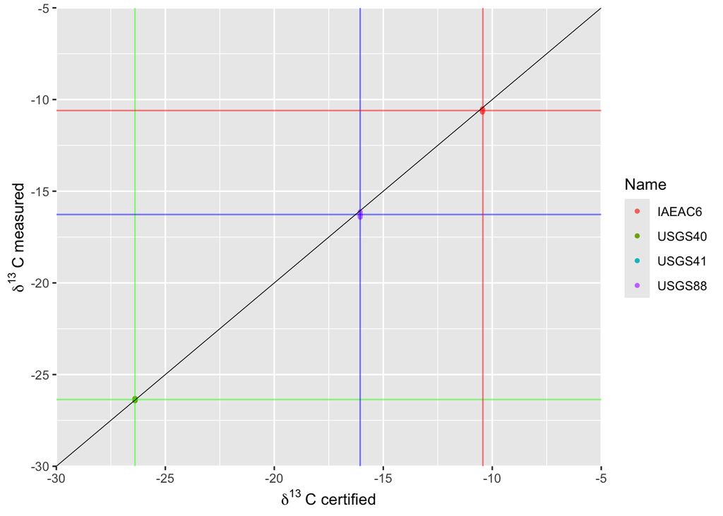

```r
F8 <-  ggplot(data = measured_standards, aes(x = d13C_certified, y = d13C_VPDB, color = Name)) +
  geom_point(size=1, show.legend = TRUE)+
coord_cartesian(xlim = c (-30, -5), ylim = c (-30, -5), expand = FALSE, default = FALSE, clip = "on")+
  labs(y = delta ^13~'C measured' , x = delta ^13~'C certified')+

  geom_vline(xintercept = -26.39,color = "green", alpha=0.5)+
  geom_hline(yintercept = -26.36, color = "green", alpha=0.5)+
  geom_vline(xintercept = -16.06,color = "blue", alpha=0.5)+
  geom_hline(yintercept = -16.27, color = "blue", alpha=0.5)+
  geom_vline(xintercept = -10.43,color = "red", alpha=0.5)+
  geom_hline(yintercept = -10.6, color = "red", alpha=0.5)+
  geom_abline( slope = 1, linewidth=0.25)

F8
```

### Calculate the under measurment for each per mil for each of these standards

The distance of USGS88 from working standard alanine = (-16.06) - (-27.18) = 11.12 The offset for USGS88 measured mean from USGS88 certified value = (-16.06) - (-16.27) = 0.21 The correction for each per mil is 0.21 / 11.12 = 0.01888

The distance of IAEAC6 from working standard alanine = (-10.45) - (-27.18) = 16.73 The offset for IAEAC6 measured mean from IAEAC6 certified value = (-10.45) - (-10.6) = 0.15 The correction for each per mil is 0.15 / 16.73 = 0.00896

The average correction for each per mil from the working standard alanine is (0.0188 + 0.00986) / 2 = 0.01392 ‰‰

i.e. This would be the correction factor for each per mil difference from the alanine working standard

So to make the scale compression correction

corrected value = measured value + (distance from -27.18 * 0.01392)

So try this on the measured USGS41 data (these data are from a subsequent different run on the instrument)

First calculate mean for measured USGS41 $\delta$ <sup>13</sup>C data

```r
#for C13
measured_usgs41_mean_d13C <- mean(measured_usgs41$d13C_VPDB)
measured_usgs41_mean_d13C <-signif(measured_usgs41_mean_d13C,4)
measured_usgs41_sd_d13C  <- sd(measured_usgs41$d13C_VPDB)
measured_usgs41_sd_d13C  <- signif(measured_usgs41_sd_d13C, 3)

measured_usgs41_mean_d13C
```

```
## [1] 36.49
```

corrected value would be

= 36.49 + ((36.49-(-27.18))x 0.01392)

= 36.49 + 0.886

= 37.37

The certified values is 37.63 so the above is an under correction but reasonably close given the large distance from the working standard of ca. 63 per mil.

What would the corrected $\delta$ <sup>13</sup>C value for the new seal be using this method:

Read in the new seal data and set factors as above.

```r
# load new seal data frame
new_seal <- read.csv("~/Desktop/2026 new seal/R-analysis/new_seal.csv")
# set factors
new_seal$Name <- as.factor(new_seal$Name)
  new_seal$Run <- as.factor(new_seal$Run)
```

Calculate mean for measured new seal $\delta$ <sup>13</sup>C data

```r
#for C13
new_seal_mean_d13C <- mean(new_seal$d13C_VPDB)
new_seal_mean_d13C <-signif(new_seal_mean_d13C,4)
new_seal_sd_d13C  <- sd(new_seal$d13C_VPDB)
new_seal_sd_d13C  <- signif(new_seal_sd_d13C, 3)

new_seal_mean_d13C
```

```
## [1] -14.34
```

```r
new_seal_sd_d13C
```

```
## [1] 0.067
```

New Seal $\delta$ <sup>13</sup>C value calibrated this way:-

= (- 14.34) + (12.84 *0.01392)

= -14.34 + 0.1787

= -14.16 ‰ VPDB.

compare to regression line (IAEAC6 and USGS40) calibrated mean value of -14.23 ‰

### So What

So a differences of 0.07‰ i.e. under corrected by 0.07‰ using the regression line method, possibly not a significant amount for routine samples BUT for the calibration of a standard I think it matters.